# JLC-CCI Exploratory Data Analysis (EDA)

**JLC variable description:**

### **Feature 42 | co_product_mix**

```
## # A tibble: 2 x 2
##   co_product_mix     n
##   <chr>          <int>
## 1 0               7415
## 2 NULL            2585
```

**Observations:**  
The *co_product_mix* feature only takes on 2 values: 0 or NULL. 0 is more common in the transactions, however it is unclear if there is any difference between a 0 value and a NULL value.

**Questions:**  
IS there a difference between 0 and NULL values?  
Take as binary values (0 = 1, NULL = 0)?  
Need further clarification.

**JLC variable description:**

### **Feature 43 | NoteExistsFlag**

```
## # A tibble: 1 x 2
##   NoteExistsFlag     n
##            <int> <int>
## 1              0 10000
```

**Observations:**  
All transactions have *recordate* NoteExistsFlag* = 0. Suspect this is a flag that indicates if a comment has been made for this transaction. Apparently underutilized feature. Consider deleting or ignorning this variable unless additional context is given.

**Questions:**  
Verify Relevancy and utilization.

**JLC variable description:**

### **Feature 44, 45, 46 | RecordDateTime, RecordDate, RecordTime**

```
## # A tibble: 45 x 2
##    dat            n
##    <chr>      <int>
##  1 08/14/2019   643
##  2 07/23/2019   642
##  3 08/05/2019   577
##  4 07/22/2019   497
##  5 07/02/2019   493
##  6 08/29/2019   472
##  7 07/03/2019   468
##  8 08/22/2019   422
##  9 08/15/2019   413
## 10 10/17/2019   359
## # ... with 35 more rows
```

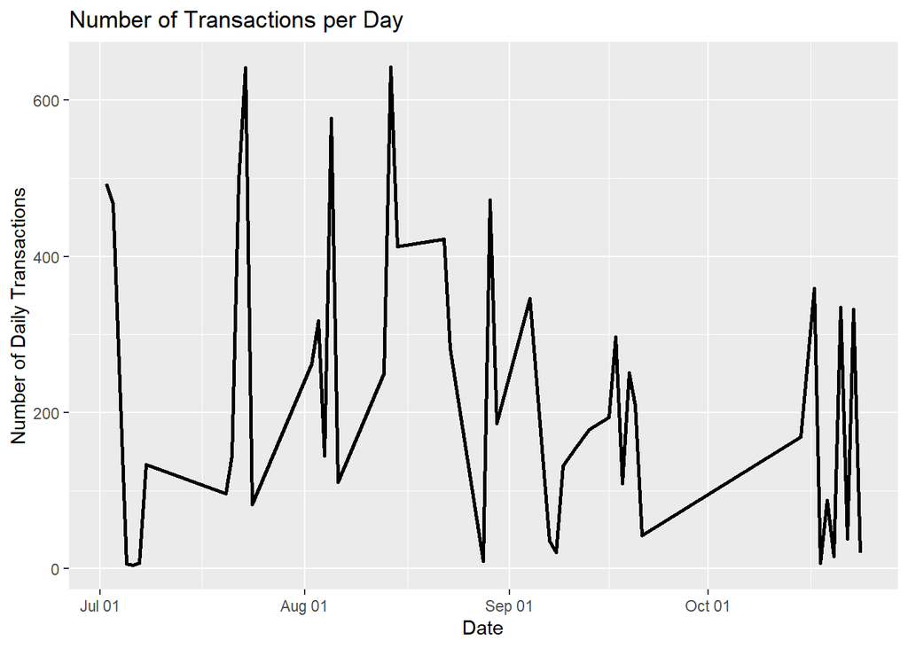

```
## # A tibble: 4 x 2
##   mon       n
##   <chr> <int>
## 1 Aug    4091
## 2 Jul    2574
## 3 Sep    1971
## 4 Oct    1364
```

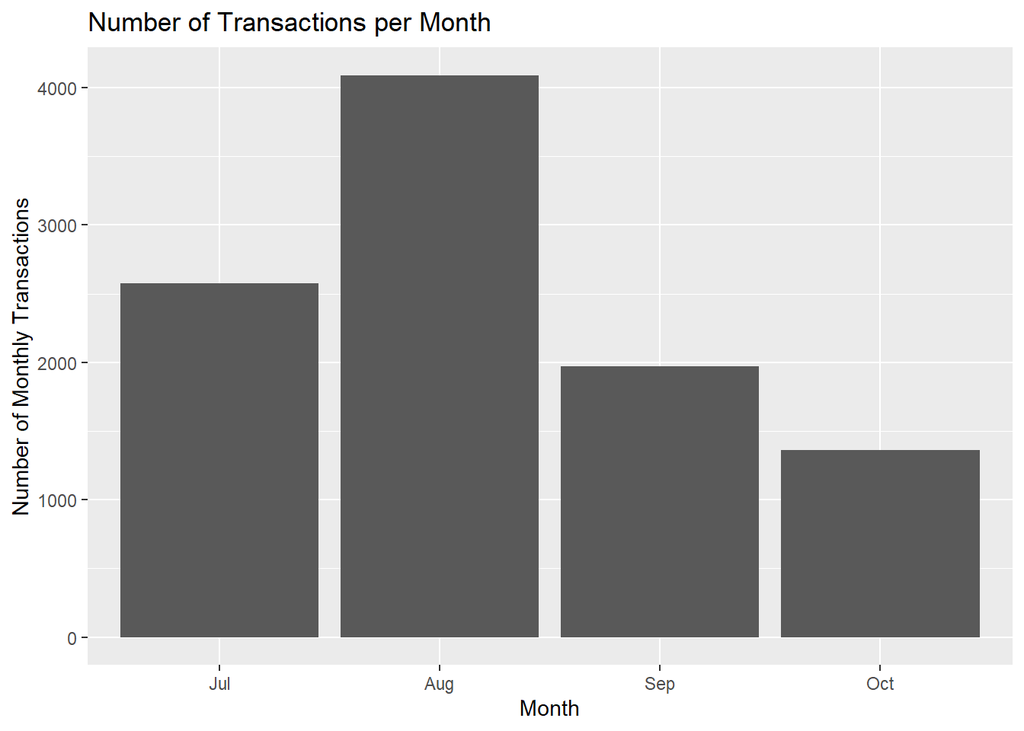

```
## # A tibble: 24 x 2
##    time      n
##    <chr> <int>
##  1 15     1808
##  2 07     1160
##  3 23     1131
##  4 13      511
##  5 08      476
##  6 10      462
##  7 09      437
##  8 12      417
##  9 16      392
## 10 14      382
## # ... with 14 more rows
```

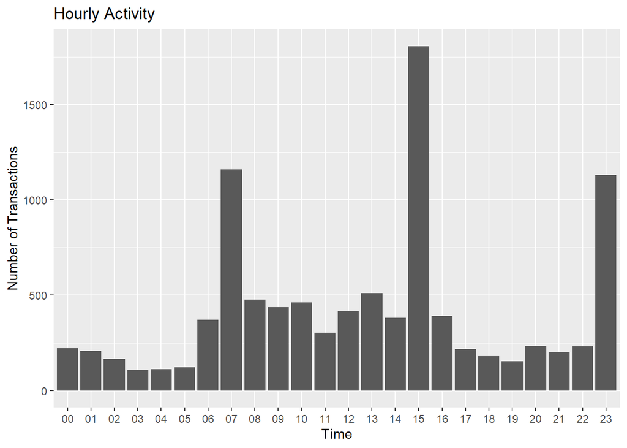

**Observations:**  
*RecordDate* and *RecordTime* display similar patterns to *trans_date* and *trans_time*, but not exactly identical. Explore relationship further.

**Questions:**  
Investigate time feature variables and how they relate to one another within the scope of each transaction.

**JLC variable description:**

### **Feature 47 | RowPointer**

```
## # A tibble: 10,000 x 2
##    RowPointer                               n
##    <chr>                                <int>
##  1 0003BFD0-8797-4DA9-A964-2141D6308062     1
##  2 001660D7-8BA7-41D5-9D4A-61F01C6E3FEC     1
##  3 00169E53-54C5-4E10-B06B-D315786D1174     1
##  4 00172EAD-26A3-4400-BBDD-735C7EA06F8A     1
##  5 0017FE4E-D4FA-48C7-8274-1F784460A140     1
##  6 001A47BF-7F63-408D-87AA-8BC7E8E222A3     1
##  7 001CFD83-9F2B-41D6-B631-1E6963191F29     1
##  8 0028445C-E605-4E1B-9C9D-3396C19F4B5E     1
##  9 00372762-CB29-473F-8DF4-EFBA3F4B3560     1
## 10 00427E26-0AA4-4752-904A-0A4F4462A29C     1
## # ... with 9,990 more rows
```

**Observations:**  
The *RowPointer* feature has no discernable pattern other than dash marks (" - ") placed at regular intervals throughout each value. A unique identifier of some sort.

**Questions:**  
Would splitting these strings up (possibly at the “-”) create some features with meaning? The only bit of consistency comes from the number of places between each “-” mark.  
Further clarification needed.

**JLC variable description:**

### **Feature 48 | CreatedBy**

```
## # A tibble: 94 x 2
##    CreatedBy                    n
##    <chr>                    <int>
##  1 "JLCLARKNT\\JLW-DB1-RK$"  6056
##  2 sa                        1037
##  3 jgraham                    644
##  4 $service                   490
##  5 dsiebold                   247
##  6 InforWM                    153
##  7 pjohnson                   132
##  8 agantz                     116
##  9 bsheets                     62
## 10 fjohnson                    59
## # ... with 84 more rows
```

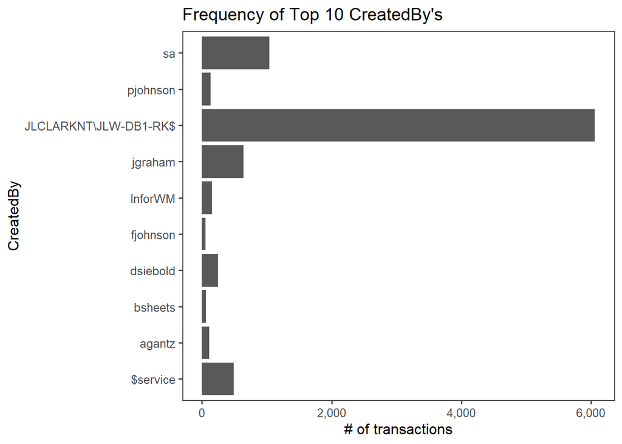

**Obeservations:**  
It appears that *createdBy* logs users in some fashion. A JLCLARK “user” is the most common type.

**Questions:**  
Does this feature log user information? If so, by what criteria?  
Need furhter clarification.

**JLC variable description:**

### **Feature 49 | UpdatedBy**

```
## # A tibble: 5 x 2
##   UpdatedBy      n
##   <chr>      <int>
## 1 sa          8557
## 2 jgraham     1002
## 3 dsiebold     340
## 4 agantz        91
## 5 plindstrom    10
```

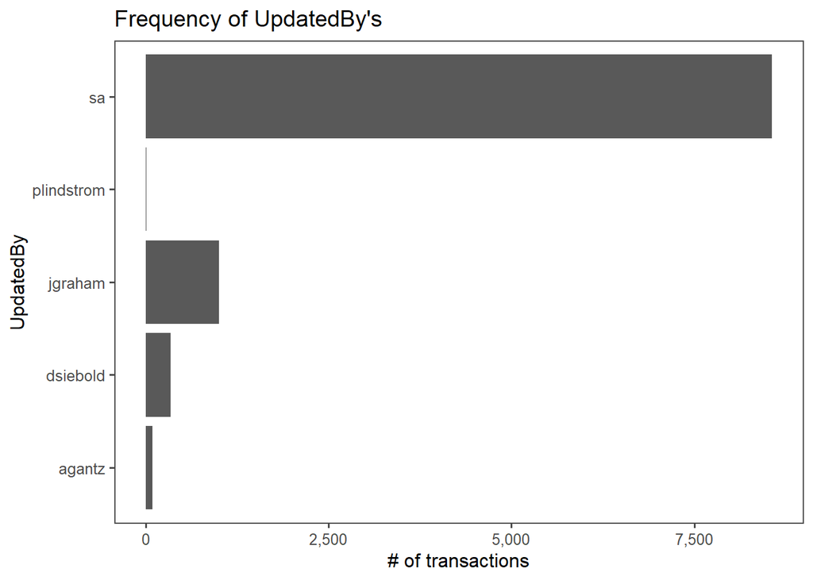

**Observations:**  
It appears that *CreatedBy* and *UpdatedBy* are related in some fashion, having similar factor levels. In fact, *UpdatedBy* levels all occur in *CreatedBy*, however there are much fewer here. “sa” is the most frequent “user”.

**Questions:**  
How does *CreatedBy* relate to *UpdatedBy*?  
How are “users” tracked?  
Need further clarification.

**JLC variable description:**

### **Feature 50, 51, 52 | CreateDateTime, CreateDate, CreateTime**

```
## # A tibble: 45 x 2
##    dat            n
##    <chr>      <int>
##  1 07/23/2019   644
##  2 08/14/2019   643
##  3 08/05/2019   577
##  4 07/22/2019   497
##  5 07/02/2019   493
##  6 08/29/2019   470
##  7 07/03/2019   468
##  8 08/22/2019   423
##  9 08/15/2019   413
## 10 10/17/2019   359
## # ... with 35 more rows
```

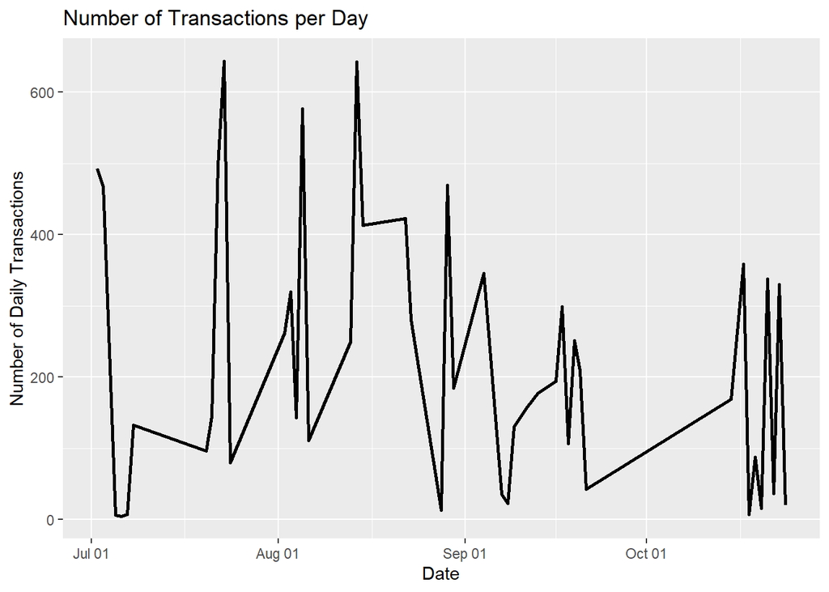

```
## # A tibble: 4 x 2
##   mon       n
##   <chr> <int>
## 1 Aug    4091
## 2 Jul    2574
## 3 Sep    1971
## 4 Oct    1364
```

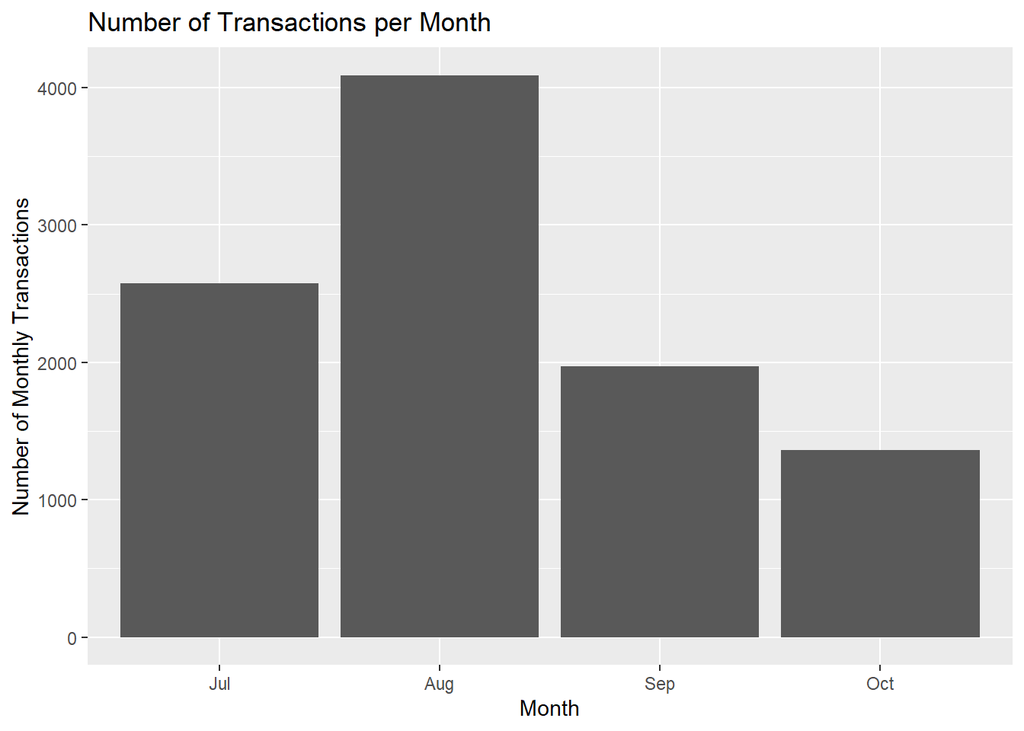

```
## # A tibble: 24 x 2
##    time      n
##    <chr> <int>
##  1 15     1805
##  2 07     1157
##  3 23     1128
##  4 13      515
##  5 08      499
##  6 10      472
##  7 09      416
##  8 12      404
##  9 16      394
## 10 14      389
## # ... with 14 more rows
```

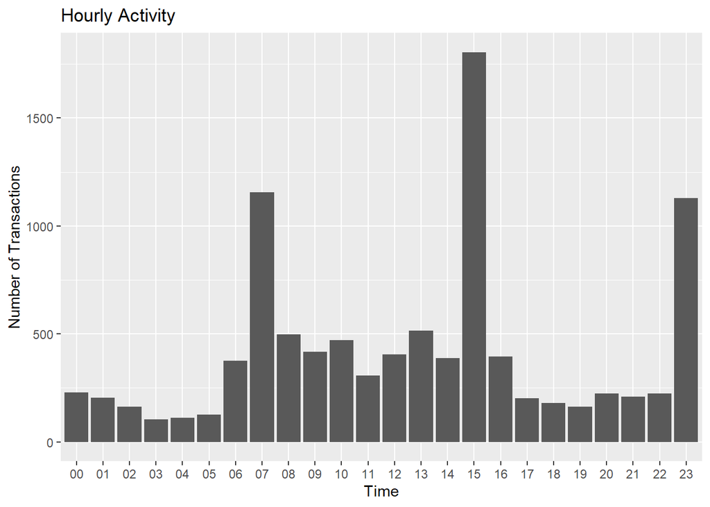

**Observations:**  
*CreateDate* and *CreateTime* display similar patterns to *trans_date*/*RecordDate* and *trans_time*.*RecordTime*, but not exactly identical. Explore relationship further.

**Questions:**  
Investigate time feature variables and how they relate to one another within the scope of each transaction.

**JLC variable description:**

### **Feature 53 | InWorkflow**

```
## # A tibble: 1 x 2
##   InWorkflow     n
##        <int> <int>
## 1          0 10000
```

**Observations:**  
Every transaction has an *InWorkFlow* = 0. Could be something to do with currently operating transaction, meaning that if the transaction was currently taking place, there may be a 1 indicator (assumption). If this is the case, all historical data will have *InWorkFlow* value = 0 and as such is not meaningful for analysis. Consider ignoring.

**Questions:**  
Verify Relevancy and utilization.

**JLC variable description:**

### **Features 54 - 59**

```
## # A tibble: 1 x 2
##   import_doc_id     n
##   <chr>         <int>
## 1 NULL          10000
```

```
## # A tibble: 1 x 2
##   container_num     n
##   <chr>         <int>
## 1 NULL          10000
```

```
## # A tibble: 1 x 2
##   parent_lot     n
##   <chr>      <int>
## 1 NULL       10000
```

```
## # A tibble: 1 x 2
##   parent_serial     n
##   <chr>         <int>
## 1 NULL          10000
```

```
## # A tibble: 1 x 2
##   RESID     n
##   <chr> <int>
## 1 NULL  10000
```

```
## # A tibble: 1 x 2
##   Uf_DocumentNum     n
##   <chr>          <int>
## 1 NULL           10000
```

**Observations:**  
All values for the features: import_doc_id, container_num, parent_lot, parent_serial, RESID, Uf_DocumentNum are equal to NULL. Likely irrelevant variables.

**Questions:**  
Verify Relevancy and utilization.

**JLC variable description:**